# Week6-李俊然

tassadar667

2021/4/8

# 1

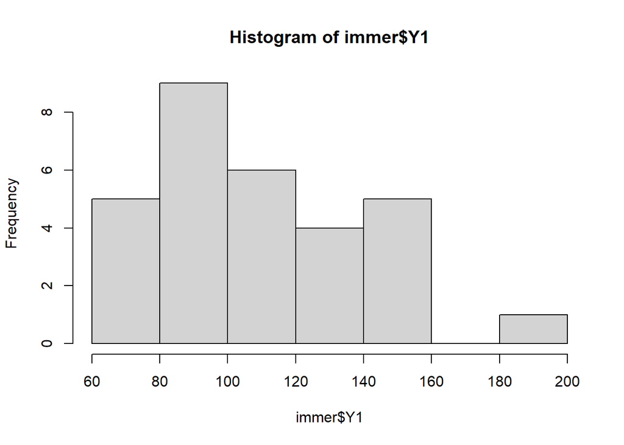

```r
library(MASS)
hist(immer$Y1)
```

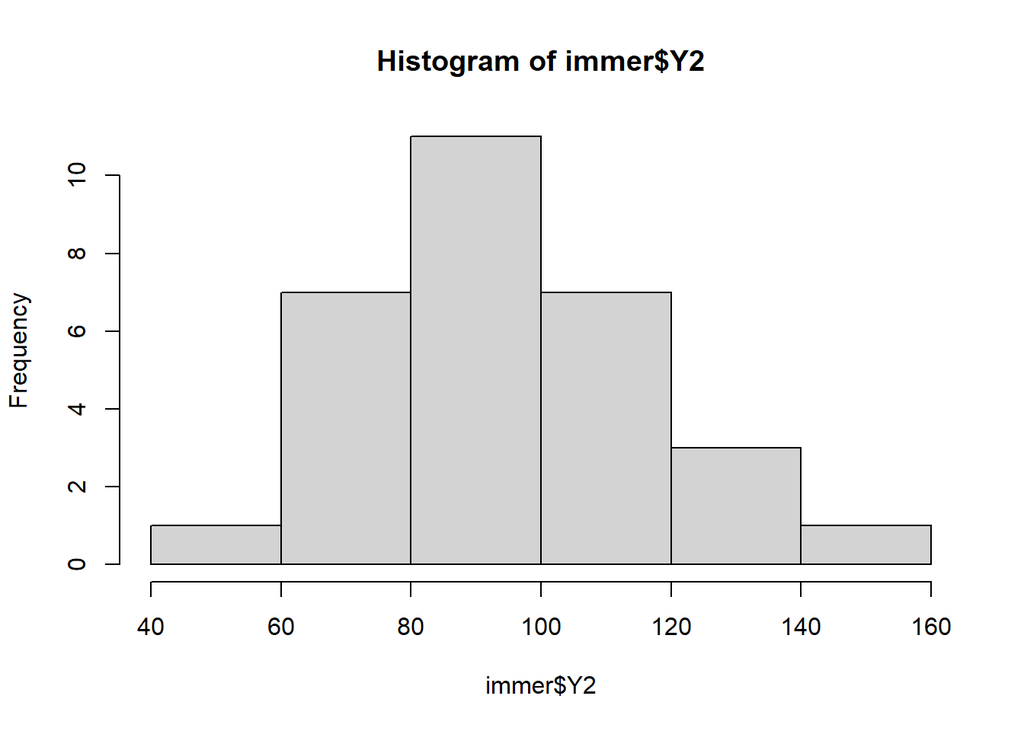

```r
hist(immer$Y2)
```

从直方图来看，两者分布不相同

```r
t.test(immer$Y1,immer$Y2,paired = TRUE)
```

```
##
##  Paired t-test
##
## data:  immer$Y1 and immer$Y2
## t = 3.324, df = 29, p-value = 0.002413
## alternative hypothesis: true difference in means is not equal to 0
## 95 percent confidence interval:
##   6.121954 25.704713
## sample estimates:
## mean of the differences
##                15.91333
```

t检验结果显示，在显著性水平为0.05水平下，可以认为两者有显著差异

```r
x=immer$Y1-immer$Y2
binom.test(sum(x>0),length(x),0.5)
```

```
##
##  Exact binomial test
##
## data:  sum(x > 0) and length(x)
## number of successes = 24, number of trials = 30, p-value = 0.001431
## alternative hypothesis: true probability of success is not equal to 0.5
## 95 percent confidence interval:
##  0.6143335 0.9228645
## sample estimates:
## probability of success
##                    0.8
```

符号检验在显著性水平为0.05的情况下未通过，认为两者有区别

```r
wilcox.test(x)
```

```
##
##  Wilcoxon signed rank test with continuity correction
##
## data:  x
## V = 368.5, p-value = 0.005318
## alternative hypothesis: true location is not equal to 0
```

Wilcox符号秩检验在显著性水平为0.05的情况下未通过，认为两者有区别

# 2

```r
c1=c(91,46,108,99,110,105,191,57,34,81)
c2=c(81,51,63,51,46,45,66,64,90,28)
binom.test(sum(c1-c2>0),length(c1),0.5)
```

```
##
##  Exact binomial test
##
## data:  sum(c1 - c2 > 0) and length(c1)
## number of successes = 7, number of trials = 10, p-value = 0.3438
## alternative hypothesis: true probability of success is not equal to 0.5
## 95 percent confidence interval:
##  0.3475471 0.9332605
## sample estimates:
## probability of success
##                    0.7
```

符号检验的结果显示在显著性水平为0.05的条件下不能拒绝原假设，即认为两者不存在显著性差异

```r
wilcox.test(c1-c2)
```

```
##
##  Wilcoxon signed rank exact test
##
## data:  c1 - c2
## V = 45, p-value = 0.08398
## alternative hypothesis: true location is not equal to 0
```

Wilcox符号秩检验的结果显示在显著性水平为0.05的条件下不能拒绝原假设，即认为两者不存在显著性差异，但是P值远小于符号检验的结果，可以认为是发生了较小概率事件或是假设不成立

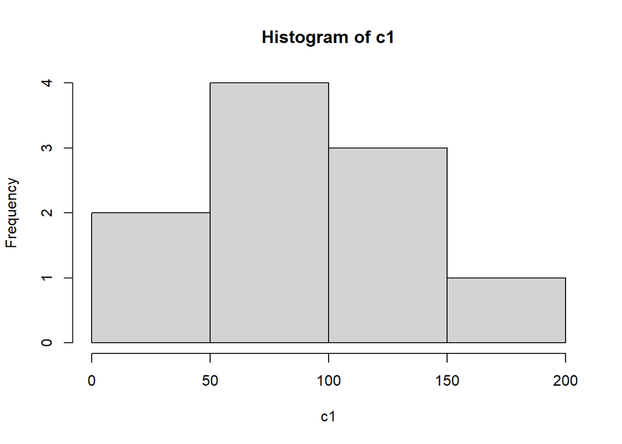

```r
hist(c1)
```

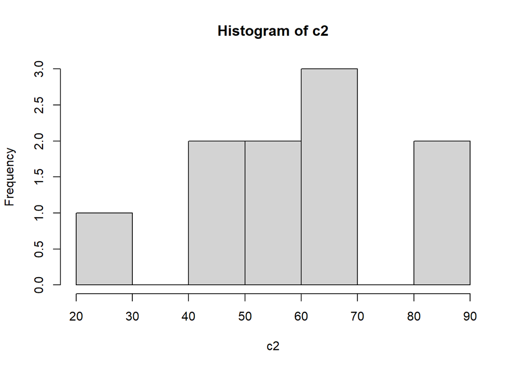

```r
hist(c2)
```

Wilcox符号秩检验效果更好，它能够在显著性水平为0.1的情况下拒绝原假设，不仅考虑到了符号也考虑到了相对大小

# 3

```r
test=function(x){
  m=median(x)
  cat("median is",m,'\n')
  temp=x-m
  n=length(temp)
  print(binom.test(sum(temp>0),n,p=0.5))
  print(wilcox.test(temp))
}

data=read.table("boston.txt",head=TRUE)
```

以下显著性水平均为0.05

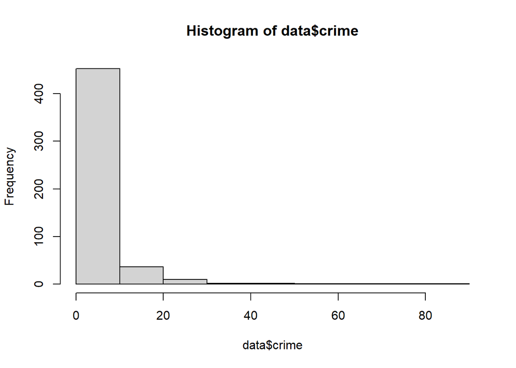

```r
hist(data$crime)
```

```r
test(data$crime)
```

```
## median is 0.25651
##
##  Exact binomial test
##
## data:  sum(temp > 0) and n
## number of successes = 253, number of trials = 506, p-value = 1
## alternative hypothesis: true probability of success is not equal to 0.5
## 95 percent confidence interval:
##  0.455556 0.544444
## sample estimates:
## probability of success
##                    0.5
##
##
##  Wilcoxon signed rank test with continuity correction
##
## data:  temp
## V = 88010, p-value = 4.012e-13
## alternative hypothesis: true location is not equal to 0
```

符号检验通过，Wilcox符号秩检验未通过，Wilcox符号秩检验更符合，犯罪率分布不对称，中位数不显著

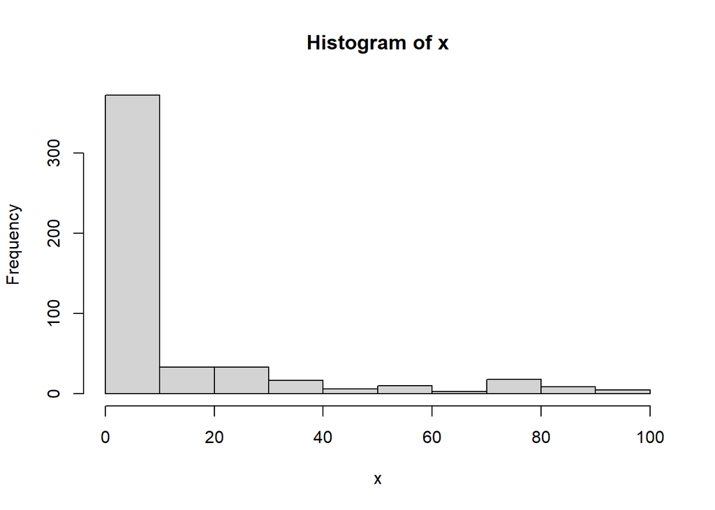

```r
x=data$biglots
hist(x)
```

```r
test(x)
```

```
## median is 0
##
##  Exact binomial test
##
## data:  sum(temp > 0) and n
## number of successes = 134, number of trials = 506, p-value < 2.2e-16
## alternative hypothesis: true probability of success is not equal to 0.5
## 95 percent confidence interval:
##  0.2268584 0.3055587
## sample estimates:
## probability of success
##              0.2648221
##
##
##  Wilcoxon signed rank test with continuity correction
##
## data:  temp
## V = 9045, p-value < 2.2e-16
## alternative hypothesis: true location is not equal to 0
```

符号检验未通过，Wilcox符号秩检验未通过，中位数不显著

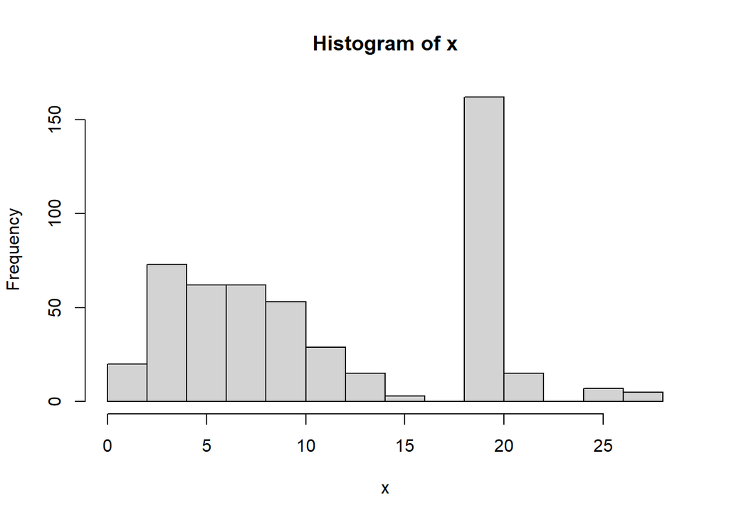

```r
x=data$industry
hist(x)
```

```r
test(x)
```

```
## median is 9.69
##
##  Exact binomial test
##
## data:  sum(temp > 0) and n
## number of successes = 248, number of trials = 506, p-value = 0.6891
## alternative hypothesis: true probability of success is not equal to 0.5
## 95 percent confidence interval:
##  0.4457411 0.5346121
## sample estimates:
## probability of success
##              0.4901186
##
##
##  Wilcoxon signed rank test with continuity correction
##
## data:  temp
## V = 79382, p-value = 7.302e-08
## alternative hypothesis: true location is not equal to 0
```

符号检验通过，Wilcox符号秩检验未通过，Wilcox符号秩检验更符合，商业区数量分布不对称，中位数不显著

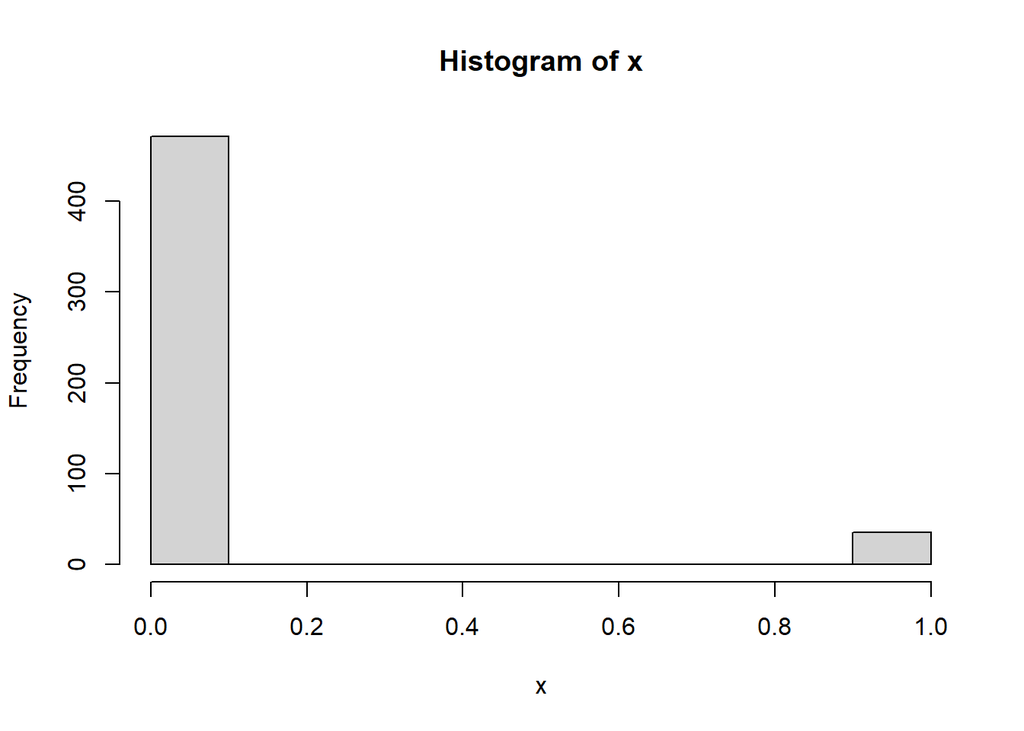

```r
x=data$river
hist(x)
```

```r
test(x)
```

```
## median is 0
##
##  Exact binomial test
##
## data:  sum(temp > 0) and n
## number of successes = 35, number of trials = 506, p-value < 2.2e-16
## alternative hypothesis: true probability of success is not equal to 0.5
## 95 percent confidence interval:
##  0.04864901 0.09488847
## sample estimates:
## probability of success
##             0.06916996
```

```
##
##  Wilcoxon signed rank test with continuity correction
##
## data:  temp
## V = 630, p-value = 3.491e-09
## alternative hypothesis: true location is not equal to 0
```

符号检验未通过，Wilcox符号秩检验未通过，中位数不显著

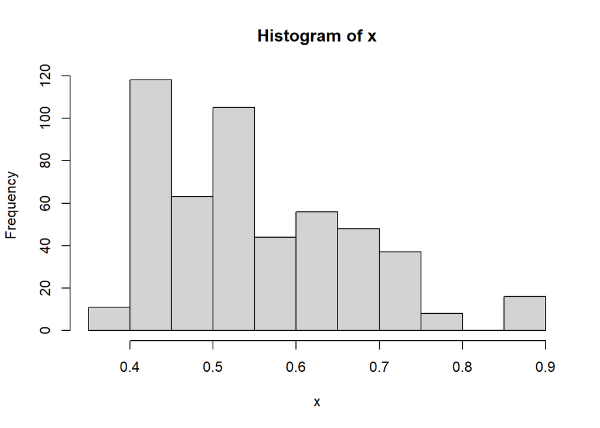

```r
x=data$nox
hist(x)
```

```r
test(x)
```

```
## median is 0.538
##
##  Exact binomial test
##
## data:  sum(temp > 0) and n
## number of successes = 234, number of trials = 506, p-value = 0.09991
## alternative hypothesis: true probability of success is not equal to 0.5
## 95 percent confidence interval:
##  0.4183496 0.5069927
## sample estimates:
## probability of success
##              0.4624506
##
##
##  Wilcoxon signed rank test with continuity correction
##
## data:  temp
## V = 64212, p-value = 0.06017
## alternative hypothesis: true location is not equal to 0
```

符号检验通过，Wilcox符号秩检验通过，但P值均较小，中位数不是很显著

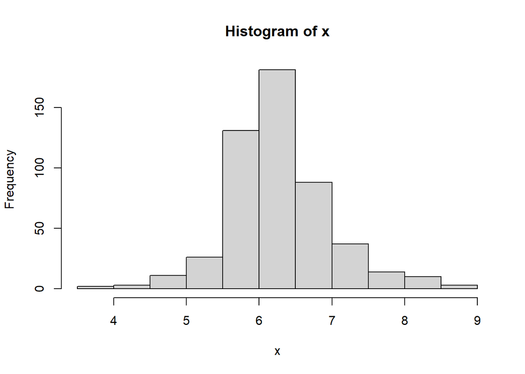

```r
x=data$rooms
hist(x)
```

```r
test(x)
```

```
## median is 6.2085
##
##  Exact binomial test
##
## data:  sum(temp > 0) and n
## number of successes = 253, number of trials = 506, p-value = 1
## alternative hypothesis: true probability of success is not equal to 0.5
## 95 percent confidence interval:
##  0.455556 0.544444
## sample estimates:
## probability of success
##                    0.5
##
##
##  Wilcoxon signed rank test with continuity correction
##
## data:  temp
## V = 68730, p-value = 0.1627
## alternative hypothesis: true location is not equal to 0
```

符号检验通过，Wilcox符号秩检验通过，但后者P值较小，原因在于分布不够对称，中位数较为显著

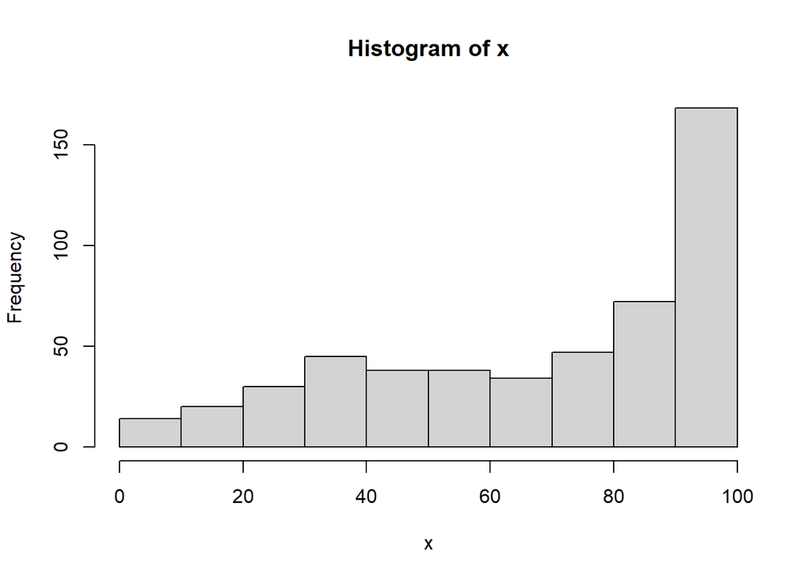

```r
x=data$age
hist(x)
```

```r
test(x)
```

```
## median is 77.5
##
##  Exact binomial test
##
## data:  sum(temp > 0) and n
## number of successes = 253, number of trials = 506, p-value = 1
## alternative hypothesis: true probability of success is not equal to 0.5
## 95 percent confidence interval:
##  0.455556 0.544444
## sample estimates:
## probability of success
##                    0.5
##
##
##  Wilcoxon signed rank test with continuity correction
##
## data:  temp
## V = 47432, p-value = 3.848e-07
## alternative hypothesis: true location is not equal to 0
```

符号检验通过，Wilcox符号秩检验未通过，Wilcox符号秩检验更符合，分布不对称，中位数不显著

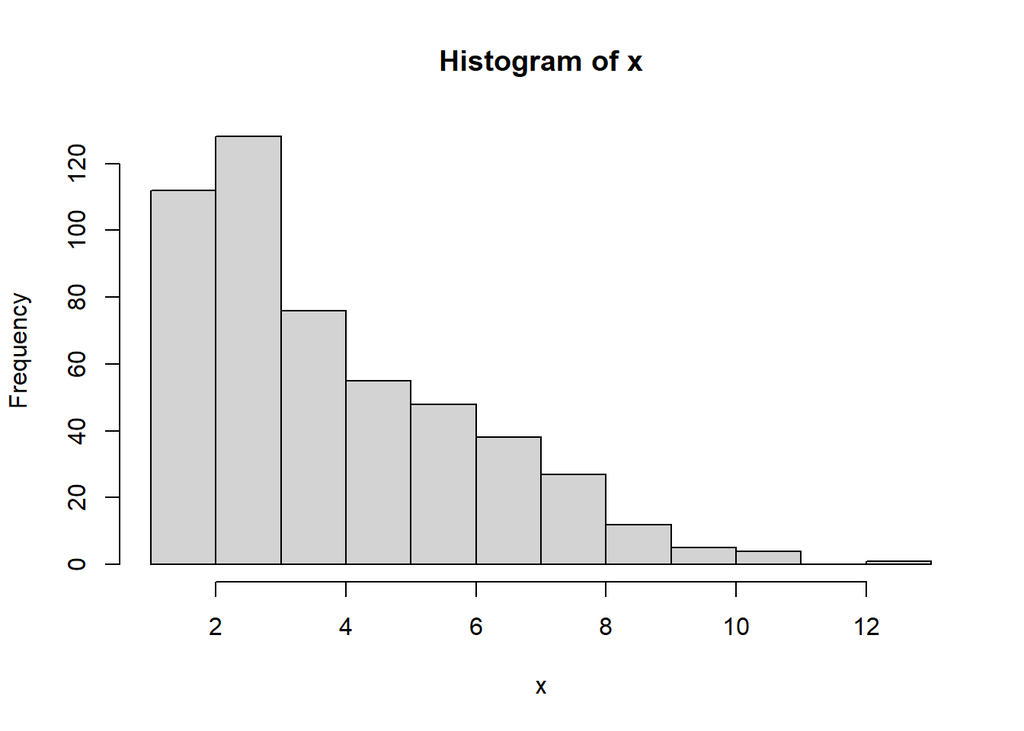

```r
x=data$distance
hist(x)
```

```r
test(x)
```

```
## median is 3.20745
##
##  Exact binomial test
##
## data:  sum(temp > 0) and n
## number of successes = 253, number of trials = 506, p-value = 1
## alternative hypothesis: true probability of success is not equal to 0.5
## 95 percent confidence interval:
##  0.455556 0.544444
## sample estimates:
## probability of success
##                    0.5
##
##
##  Wilcoxon signed rank test with continuity correction
##
## data:  temp
## V = 76270, p-value = 0.0002265
## alternative hypothesis: true location is not equal to 0
```

符号检验通过，Wilcox符号秩检验未通过，Wilcox符号秩检验更符合，分布不对称，中位数不显著

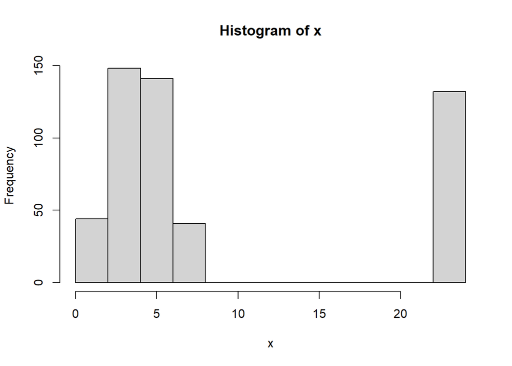

```r
x=data$highway
hist(x)
```

```r
test(x)
```

```
## median is 5
##
##  Exact binomial test
##
## data:  sum(temp > 0) and n
## number of successes = 199, number of trials = 506, p-value = 1.806e-06
## alternative hypothesis: true probability of success is not equal to 0.5
## 95 percent confidence interval:
##  0.3504628 0.4373529
## sample estimates:
## probability of success
##              0.3932806
##
##
##  Wilcoxon signed rank test with continuity correction
##
## data:  temp
## V = 52707, p-value = 7.827e-11
## alternative hypothesis: true location is not equal to 0
```

符号检验未通过，Wilcox符号秩检验未通过，中位数不显著

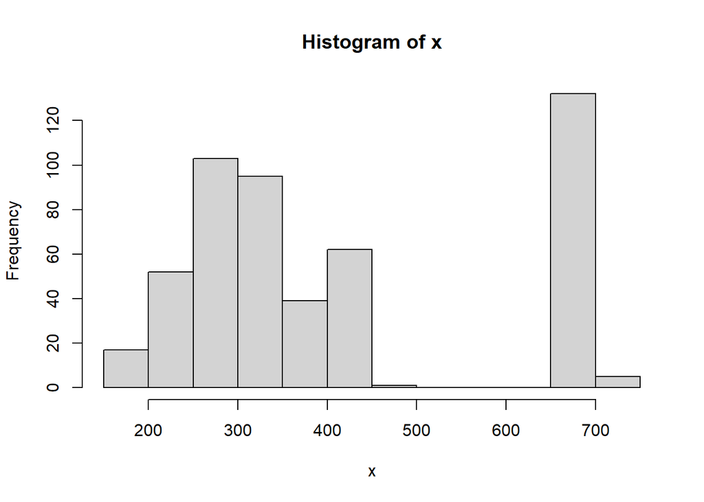

```r
x=data$tax
hist(x)
```

```r
test(x)
```

```
## median is 330
##
##  Exact binomial test
##
## data:  sum(temp > 0) and n
## number of successes = 250, number of trials = 506, p-value = 0.8241
## alternative hypothesis: true probability of success is not equal to 0.5
## 95 percent confidence interval:
##  0.4496650 0.5385469
## sample estimates:
## probability of success
##              0.4940711
##
##
##  Wilcoxon signed rank test with continuity correction
##
## data:  temp
## V = 82156, p-value = 1.167e-10
## alternative hypothesis: true location is not equal to 0
```

符号检验通过，Wilcox符号秩检验未通过，Wilcox符号秩检验更符合，分布不对称，中位数不显著

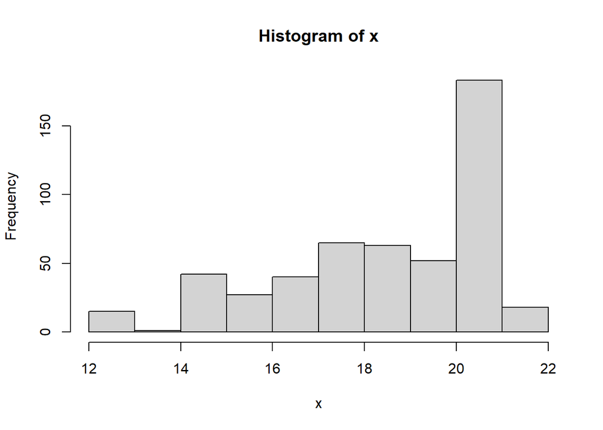

```r
x=data$ptratio
hist(x)
```

```r
test(x)
```

```
## median is 19.05
##
##  Exact binomial test
##
## data:  sum(temp > 0) and n
## number of successes = 253, number of trials = 506, p-value = 1
## alternative hypothesis: true probability of success is not equal to 0.5
## 95 percent confidence interval:
##  0.455556 0.544444
## sample estimates:
## probability of success
##                    0.5
##
##
##  Wilcoxon signed rank test with continuity correction
##
## data:  temp
## V = 50002, p-value = 1.655e-05
## alternative hypothesis: true location is not equal to 0
```

符号检验通过，Wilcox符号秩检验未通过，Wilcox符号秩检验更符合，分布不对称，中位数不显著

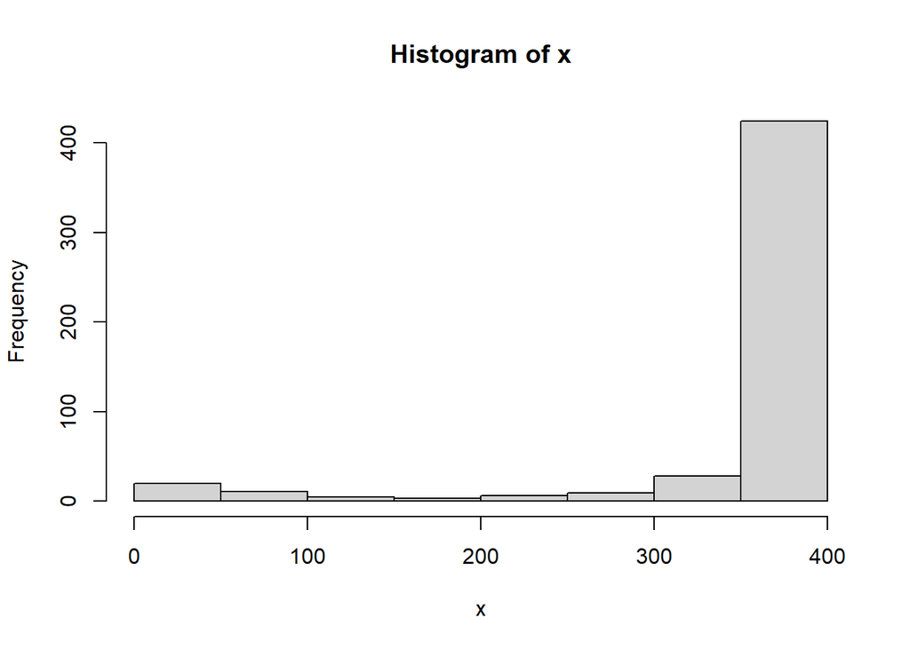

```r
x=data$black
hist(x)
```

```r
test(x)
```

```
## median is 391.44
##
##  Exact binomial test
##
## data:  sum(temp > 0) and n
## number of successes = 253, number of trials = 506, p-value = 1
## alternative hypothesis: true probability of success is not equal to 0.5
## 95 percent confidence interval:
##  0.455556 0.544444
## sample estimates:
## probability of success
##                    0.5
##
##
##  Wilcoxon signed rank test with continuity correction
##
## data:  temp
## V = 45633, p-value = 1.777e-08
## alternative hypothesis: true location is not equal to 0
```

符号检验通过，Wilcox符号秩检验未通过，Wilcox符号秩检验更符合，分布不对称，中位数不显著

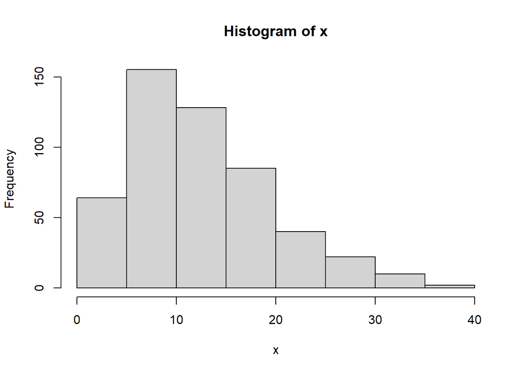

```r
x=data$lowstat
hist(x)
```

```r
test(x)
```

```
## median is 11.35
##
##  Exact binomial test
##
## data:  sum(temp > 0) and n
## number of successes = 253, number of trials = 506, p-value = 1
## alternative hypothesis: true probability of success is not equal to 0.5
## 95 percent confidence interval:
##  0.455556 0.544444
## sample estimates:
## probability of success
##                    0.5
##
##
##  Wilcoxon signed rank test with continuity correction
##
## data:  temp
## V = 70765, p-value = 0.04395
## alternative hypothesis: true location is not equal to 0
```

符号检验通过，Wilcox符号秩检验未通过，Wilcox符号秩检验更符合，分布不对称，中位数不显著

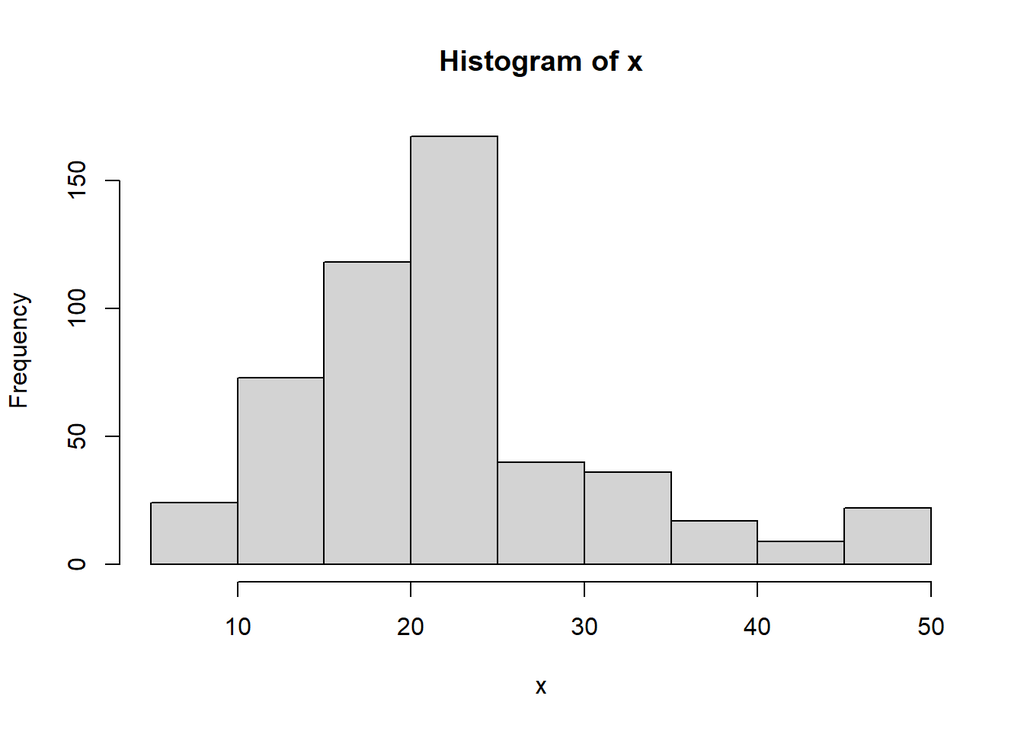

```r
x=data$value
hist(x)
```

```r
test(x)
```

```
## median is 21.2
##
##  Exact binomial test
##
## data:  sum(temp > 0) and n
## number of successes = 250, number of trials = 506, p-value = 0.8241
## alternative hypothesis: true probability of success is not equal to 0.5
## 95 percent confidence interval:
##  0.4496650 0.5385469
## sample estimates:
## probability of success
##              0.4940711
##
##
##  Wilcoxon signed rank test with continuity correction
##
## data:  temp
## V = 66112, p-value = 0.3182
## alternative hypothesis: true location is not equal to 0
```

符号检验通过，Wilcox符号秩检验通过，但后者P值较小，原因在于分布不够对称，中位数较为显著

## 总结

对于中位数的符号检验，除非出现大量相同数据，否则中位数两边的样本数量差距应该较小，但是符号检验没有考虑到样本离中位数的距离